# Clustering Pseudotime Inference on Skin Cell scRNA-seq

Matt Karikomi

2018-11-11

This is an example of clustering, marker identification and pseudotime inference on a set of skin cells.

## Load and Preprocess Data

Load and log transform the data

```r
library(RSoptSC)
data("GSE67602_Joost")
logdata <- log10(GSE67602_Joost$data + 1)
```

Apply number of features and exclusion threshold

```r
gene_expression_threshold <- 0.03
n_features <- 3000
filtered_data <- SelectData(logdata, gene_expression_threshold, n_features)
```

## Compute the Similarity Matrix

Run L2R2 on the processed data, outputting the number of iterations and value of the objective.

```r
sim <- SimilarityM(lambda = 0.05, data = filtered_data$M_variable)
```

[1] “Iter Err” 1, 20.597435 2, 19.520815 3, 18.476136 4, 17.491670 5, 16.569212 6, 15.705525 7, 7.770185 8, 0.415020 9, 0.356815 10, 0.339246 11, 0.328628 12, 0.318293 13, 0.307808 14, 0.297460 15, 0.287398 16, 0.277677 17, 0.268311 18, 0.253743 19, 0.232315 20, 0.204575 21, 0.170748 22, 0.130527 23, 0.083237 24, 0.041469 25, 0.100519 [1] “not reach epsilon”

## Cluster the Cells

Infer cluster number using spectra of the ensemble Laplacian.

```r
n_clusters <- CountClusters(data = sim$W)
```

Factor the similarity matrix such that W = HxH’, using the computed cluster number for the rank of H.

```r
H <- NNLM::nnmf(sim$W, n_clusters, rel.tol = 1e-6);
```

Assign cluster labels to the cells.

```r
labels <- apply(H$W, 1, function(x){
  which(x == max(x))})
```

## Find cluster marker genes.

Previously, we clustered the cells using L2R2/Sym-NMF, now we analyze the markers of the clusters. We look at the normalized expression values of all genes using pre-selection parameters similar to the pre-clustering selection parameters.

[figure not shown]

```r
markers <- GetMarkerTable(counts_data = logdata,
                          cluster_labels = labels,
                          H = H$W,
                          gene_expression_threshold = gene_expression_threshold,
                          n_features = n_features)
heatplot <- MarkerHeatmap(logdata,labels,markers,n_markers = 5)
```

## Pseudotime Inference

Compute distances on the similarity matrix. If the truncated graph has multiple components, join them to improve inter-cluster distance estimation.

```r
mapped <- RepresentationMap(similarity_matrix = sim$W,
                            join_components = TRUE)
```

[1] “computing flat embedding”

Compute cluster-cluster graph and find the root cluster.

```r
cluster_ptime <- FindRootCluster(cluster_labels = labels,
                                 flat_embedding = mapped$flat_embedding,
                                 dist_graph = mapped$dist_graph,
                                 dist_flat = mapped$dist_flat,
                                 reverse = FALSE)
```

Compute the cell-cell graph and find the root cell.

```r
root_cell <- FindRootCell(cluster_order_by = "distance",
                           cell_order_by = "distance",
                           graph_cluster_mst = cluster_ptime$cluster_mst,
                           dist_graph  = mapped$dist_graph,
                           dist_flat = mapped$dist_flat,
                           cluster_labels = labels,
                           root_cluster = cluster_ptime$root_cluster)
```

## Pseudotime Visualization

Compute the directional minimum spanning tree on the cluster-cluster graph for visualization.

```r
cluster_predecessors <- GetPredecessors(cluster_ptime$cluster_mst, cluster_ptime$root_cluster)
cluster_dtree <- GetDominatorTree(cluster_predecessors, cluster_ptime$graph_cluster)
PlotLineage(cluster_dtree)
```

Called from: PlotLineage(cluster_dtree)

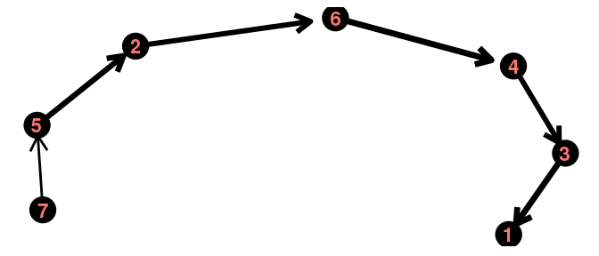

Color lineage plot by Pseudotime:

```r
ptime_distance <- cluster_ptime$cluster_adj_matrix[cluster_ptime$root_cluster,]
ptime_distance <- 1 + ptime_distance/max(ptime_distance)
PlotLineage(cluster_dtree, node_color = ptime_distance)
```

Called from: PlotLineage(cluster_dtree, node_color = ptime_distance)

[figure not shown]

Compute the path-length vector from root, and plot the cells in the previously computed low-dimensional embedding.

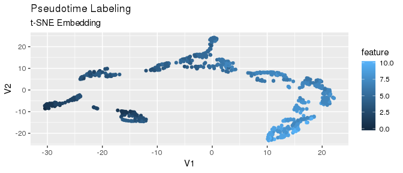

```r
pseudotime <- mapped$dist_graph[root_cell,]

# plot pseudotime
FeatureScatterPlot(flat_embedding = mapped$flat_embedding,
                         feature = pseudotime,
                         title = "Pseudotime Labeling",
                         subtitle = "t-SNE Embedding")
```

## Plot Features

Plot Expression of Krt10 in t-SNE Space:

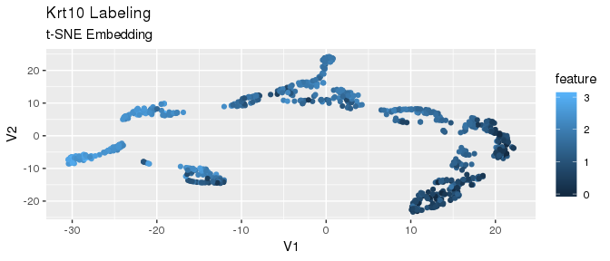

```r
gene_index <- which(GSE67602_Joost$gene_names == 'Krt10')
labeling <- logdata[gene_index,]

# plot features
FeatureScatterPlot(flat_embedding = mapped$flat_embedding,
                    feature = labeling,
                    title = "Krt10 Labeling",
                    subtitle = "t-SNE Embedding")
```

Color lineage plot by Krt10 expression:

```r
feature_avg <- AvgFeatureExpression(cluster_labels = labels,
                                    M = logdata,
                                    feature = "Krt10",
                                    feature_list = GSE67602_Joost$gene_names)
PlotLineage(cluster_dtree, node_color = feature_avg)
```

Called from: PlotLineage(cluster_dtree, node_color = feature_avg)

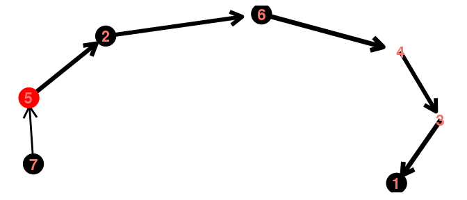